# Midterm Class 2

# Housekeeping

- Oral exam scheduler is up and linked on the schedule
- I will post details about the oral component, but it is not something you should feel the need to study for. You did the work, this is just a chance to make sure I understand what you did and why you did it.
- Midterm due date is today at midnight. The late penalty will start to be applied after Sunday at midnight. Your time is your own to manage.

Today we are going to focus more on pulling pieces together to make a cohesive narrative. And also some of the details of the data that have been more difficult to grasp.

Let’s read in the data:

```r
#code to read in data
# EJI
library(sf)
library(tidyverse)
library(ggthemes)
library(viridis)
library(patchwork)

eji_data <- st_read("~/Dropbox/!Middlebury/Teaching/STAT 118/S2026/S2026_R_Proj/midterm/eji_sf.gpkg")
# YRBS
yrbs_data <- read_csv("~/Dropbox/!Middlebury/Teaching/STAT 118/S2026/S2026_R_Proj/midterm/yrbss_2024.csv")
```

# Groups - Opening Discussion

In your groups, take turns sharing where you are with your midterm projects.

1. What are you investigating? Briefly explain your question and what you’ve found so far.
2. What has surprised you? Have you noticed any interesting patterns or unexpected results?
3. Where are you stuck? Is there something you’re struggling to understand, analyze, or visualize?
4. What’s your next step? What would you like to investigate further, and how might you approach it?

# Percentile Rank

In the EJI dataset, many variables are provided both as original measurements (such as percentages or concentrations) and as percentile ranks. Percentile rank tells us where an observation falls relative to all the other observations in a dataset. For example, a census tract at the 75th percentile for poverty has a higher poverty percentage than approximately 75% of census tracts.

```r
# This is how I made the quartiles, but it took so long to run that I wrote them out to a csv file and then read that in for the next step
# I set this code to not be evaluated when the document renders to prevent it taking forever.
# But I still wanted to show it to you.

quartiles <- eji_data |>
  summarize(Q1 = quantile(E_POV200, 0.25, na.rm = TRUE),
            Q2 = median(E_POV200, na.rm = TRUE),
            Q3 = quantile(E_POV200, 0.75, na.rm = TRUE))
```

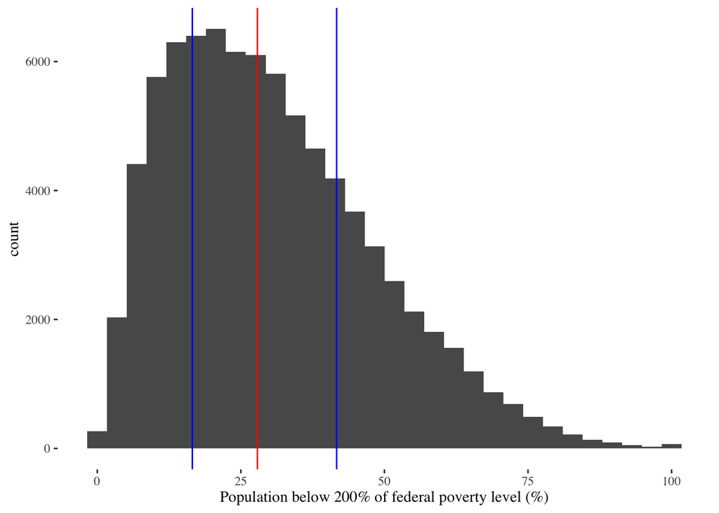

```r
quartiles <- read_csv( "./courses/STAT118/data/eji_pov_quartiles.csv")

eji_data |>
  ggplot(aes(x=E_POV200)) +
  geom_histogram() +
  geom_vline(xintercept=quartiles$Q1, color="blue") +
  geom_vline(xintercept=quartiles$Q2, color="red") +
  geom_vline(xintercept=quartiles$Q3, color="blue") +
  labs(x = "Population below 200% of federal poverty level (%)") +
  theme_tufte()
```

This first histogram shows the distribution of poverty percentages across census tracts in the United States. The vertical lines mark the lower quartile (25th percentile), median (50th percentile), and upper quartile (75th percentile). Each interval between these values contains approximately 25% of the census tracts, even though the intervals cover different ranges of poverty percentages.

The next plot shows how the original poverty percentages relate to their percentile ranks. Notice that the relationship is not linear. Where observations are concentrated in the original distribution, percentile ranking stretches them apart. Where observations are spread out, percentile ranking compresses the distances between them.

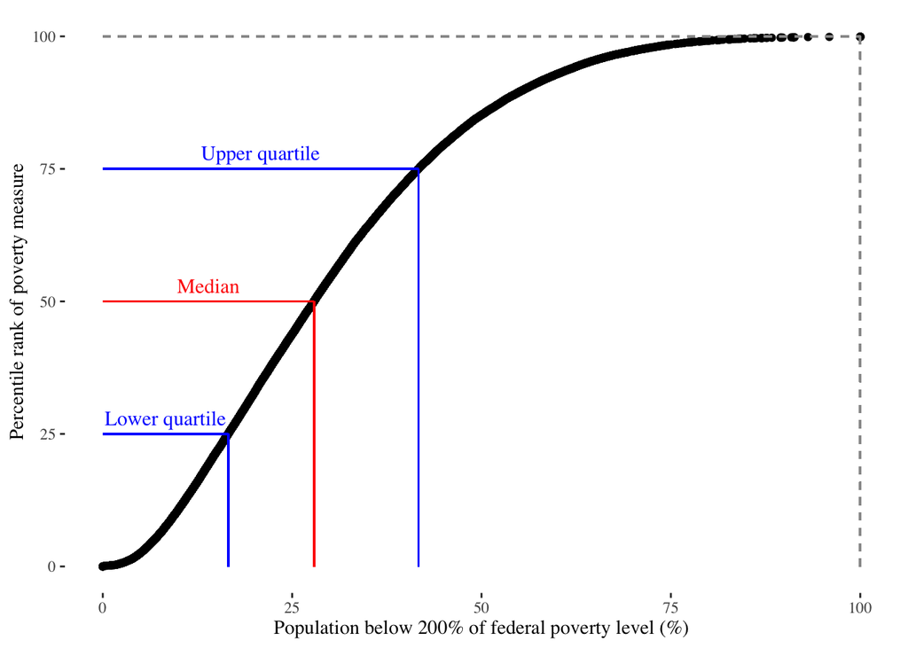

```r
eji_data |>
  filter(STATE_NAME == "California") |>
  ggplot(aes(y = EPL_POV200 * 100, x = E_POV200)) +
  geom_point() +
  geom_segment(aes(x = quartiles$Q1, xend = quartiles$Q1,
                   y = 0, yend = 25), color = "blue") +
  geom_segment(aes(x = 0, xend = quartiles$Q1,
                   y = 25, yend = 25), color = "blue") +
  geom_segment(aes(x = quartiles$Q2, xend = quartiles$Q2,
                   y = 0, yend = 50), color = "red") +
  geom_segment(aes(x = 0, xend = quartiles$Q2,
                   y = 50, yend = 50), color = "red") +
  geom_segment(aes(x = quartiles$Q3, xend = quartiles$Q3,
                   y = 0, yend = 75), color = "blue") +
  geom_segment(aes(x = 0, xend = quartiles$Q3,
                   y = 75, yend = 75), color = "blue") +
  annotate("text", x = quartiles$Q1 / 2, y = 28,
         label = "Lower quartile", color = "blue", size = 4) +
  annotate("text", x = quartiles$Q2 / 2, y = 53,
         label = "Median", color = "red", size = 4) +
  annotate("text", x = quartiles$Q3 / 2, y = 78,
         label = "Upper quartile", color = "blue", size = 4) +
  geom_segment(aes(x = 100, xend = 100,
                   y=0, yend=100),
             color = "grey60", linetype = "dashed") +
  geom_segment(aes(x = 0, xend = 100,
                   y=100, yend=100),
             color = "grey60", linetype = "dashed") +
  labs(x = "Population below 200% of federal poverty level (%)",
       y = "Percentile rank of poverty measure") +
  theme_tufte()
```

## Why does this matter for data analysis?

The following plots explore the relationship between poverty and coronary heart disease in California census tracts. The first uses the original measurements, while the subsequent plots replace one or both variables with their percentile ranks.

Notice how the shape of the relationship changes as we switch from original values to percentile ranks. The underlying observations haven’t changed, but the distances between them have. Percentile ranks preserve the order of observations while changing how far apart they appear.

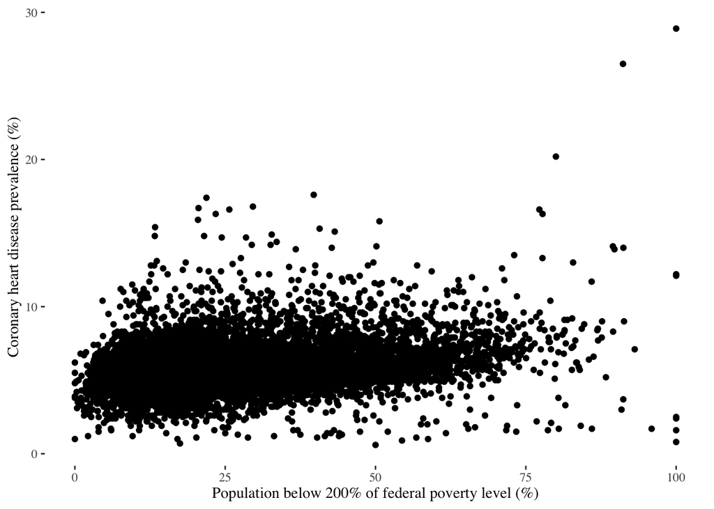

```r
#E_CHD Percentage of individuals with coronary heart disease 2024 CDC PLACES Data
#EPL_CHD Percentile rank of percentage of individuals with coronary heart disease

eji_data |>
  filter(STATE_NAME=="California") |>
  ggplot(aes(x=E_POV200, y=E_CHD)) +
  geom_point() +
  labs(x = "Population below 200% of federal poverty level (%)",
       y = "Coronary heart disease prevalence (%)") +
  theme_tufte()
```

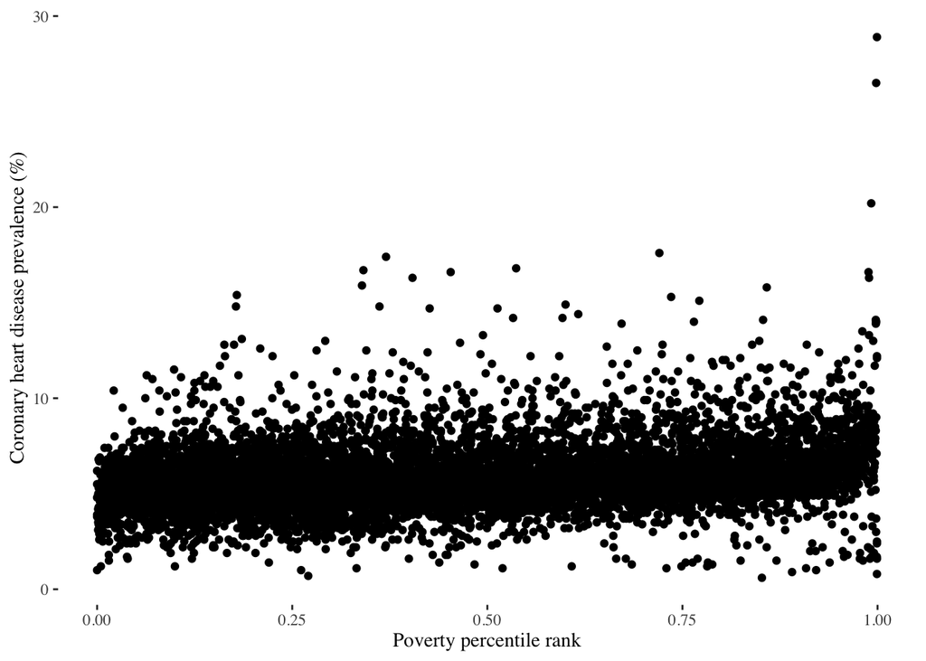

```r
eji_data |>
  filter(STATE_NAME=="California") |>
  ggplot(aes(x=EPL_POV200, y=E_CHD)) +
  geom_point() +
  labs(x = "Poverty percentile rank",
       y = "Coronary heart disease prevalence (%)") +
  theme_tufte()
```

The next two plots show the same data using points and hexagonal bins. When many observations overlap, it can be difficult to see where the data are concentrated. Hexagonal bins help reveal those concentrations by counting the observations within each hexagon.

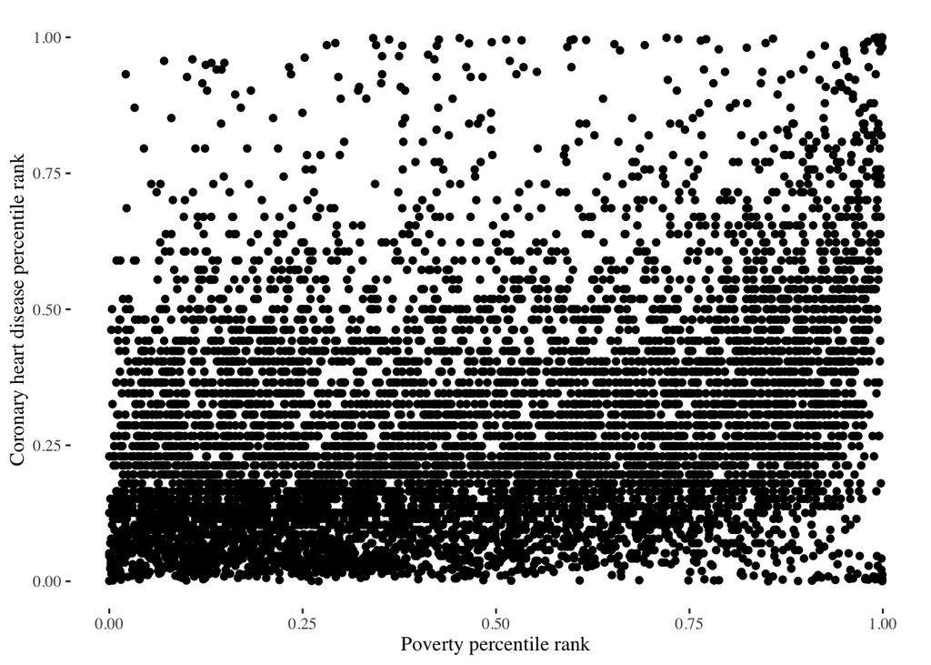

```r
eji_data |>
  filter(STATE_NAME=="California") |>
  filter(E_ROAD>50) |>
  ggplot(aes(x=EPL_POV200, y=EPL_CHD)) +
  geom_point() +
  labs(x = "Poverty percentile rank",
       y = "Coronary heart disease percentile rank") +
  theme_tufte()
```

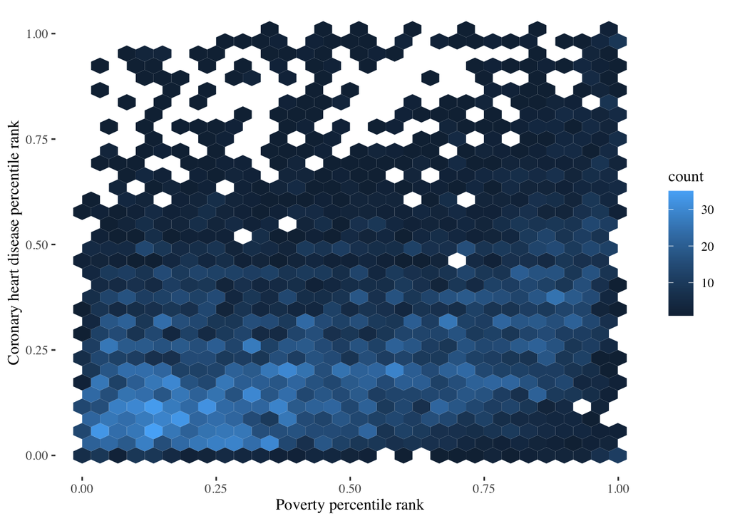

```r
eji_data |>
  filter(STATE_NAME=="California") |>
  filter(E_ROAD>50) |>
  ggplot(aes(x=EPL_POV200, y=EPL_CHD)) +
  geom_hex() +
  labs(x = "Poverty percentile rank",
       y = "Coronary heart disease percentile rank") +
  theme_tufte()
```

Neither original values nor percentile ranks are inherently better. Original values tell us about the magnitude of differences between census tracts, while percentile ranks tell us about their relative positions. Which is more useful depends on the question we are asking.

# Questions

1. How do you figure out the units for the EJI dataset.
2. Is there a way to combine different columns based on the data in the rows for example: wanting to combine columns 1 and 2 if the answer in a row is “yes” for both columns.
3. Is there a way to fct_collapse from different columns?
4. For writing our report, are we supposed to write different results sections under each figure? Or one large results section after all of the figures?
5. What is the best way to account for the survey weights applied to YRBSS?
6. How do you want us to make our table of summary statistics (I’m assuming with Kable)/what do you mean by that? How much should we include?
7. How do we add a caption to our figures? Do we make them images and add captions to those, or is there another way to add it to the figures themselves?
8. I am wondering about color scales for a bar graph based on percentages. Also does it help to break up the code into a few chunks while doing trial and error or is it best to have one long string?

# Putting together a narrative

Let’s return to the relationship between poverty and coronary heart disease that we examined above. I want to use this plot below as a jumping off point:

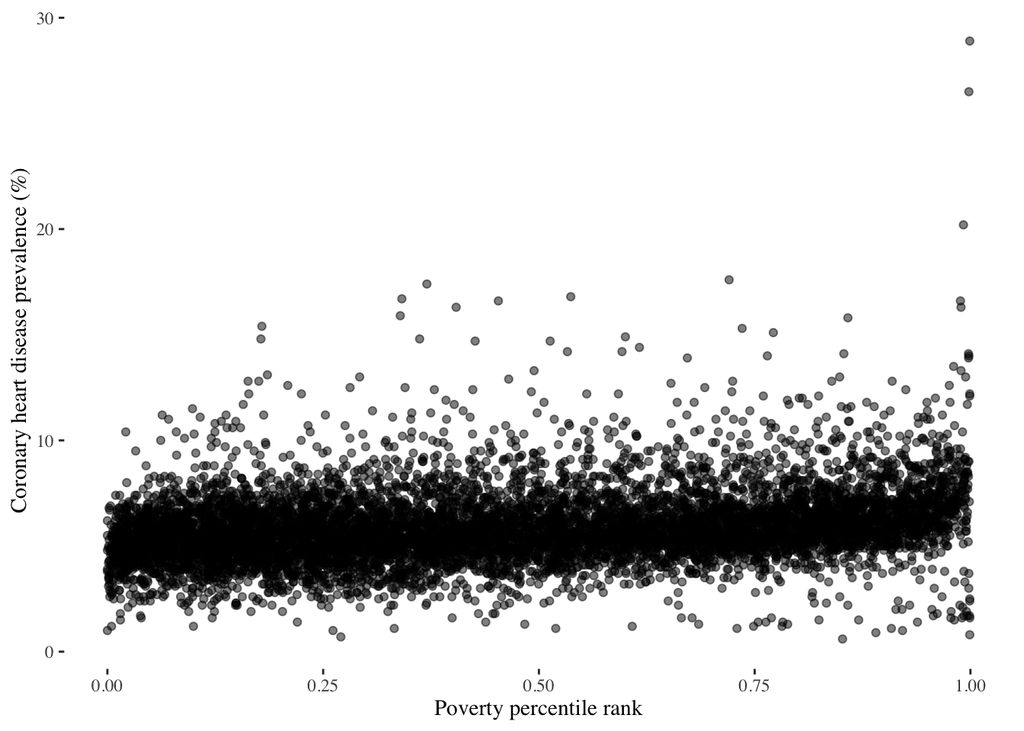

```r
eji_data |>
  filter(STATE_NAME=="California") |>
  ggplot(aes(x=EPL_POV200, y=E_CHD)) +
  geom_point(alpha=0.5) +
  labs(x = "Poverty percentile rank",
       y = "Coronary heart disease prevalence (%)") +
  theme_tufte()
```

What next? I see a clear trend of increasing heart disease with increasing poverty. The percentile rank helps to stretch out the low values on the poverty axis.

There is a lot of vertical spread in the data though. I am wondering if there is another variable that interacts with poverty and explains some of the vertical distribution.

Age is a significant factor in coronary heart disease, so let’s look at that first. Using E_AGE65 and EPL_AGE65 which are the percentage of persons aged 65 and older and the percentile rank of E_AGE65, respectively. I’m messing around with just California here for a bit.

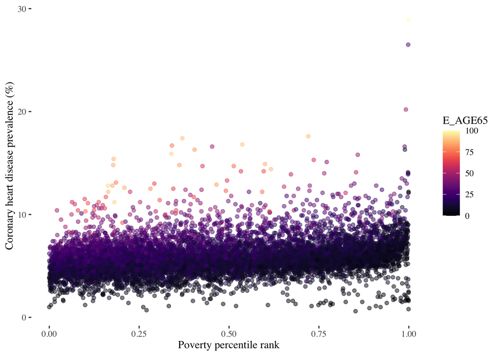

```r
#E_AGE65 Percentage of persons aged 65 and older
#EPL_AGE65 Percentile rank of the percentage of persons aged 65 and older
#E_DIABETES Percentage of persons with diabetes
#EPL_DIABETES Percentile rank of the Percentage of persons with diabetes
#SPL_EBM Summation of the Environmental Burden Module percentile ranks No Value
#RPL_EBM Percentile ranks of Environmental Burden Mod

eji_data |>
  filter(STATE_NAME=="California") |>
  ggplot(aes(x=EPL_POV200, y=E_CHD)) +
  geom_point(aes(color=E_AGE65), alpha=0.5) +
  scale_color_viridis(option="magma") +
  labs(x = "Poverty percentile rank",
       y = "Coronary heart disease prevalence (%)") +
  theme_tufte()
```

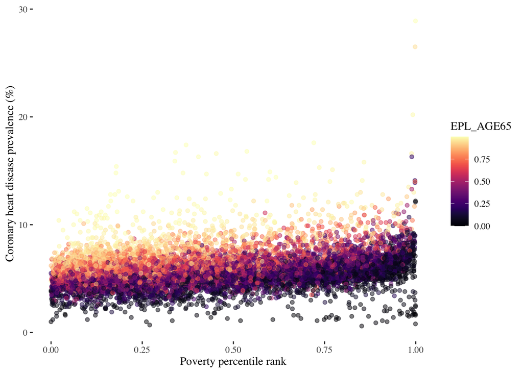

```r
eji_data |>
  filter(STATE_NAME=="California") |>
  ggplot(aes(x=EPL_POV200, y=E_CHD)) +
  geom_point(aes(color=EPL_AGE65), alpha=0.5) +
  scale_color_viridis(option="magma") +
  labs(x = "Poverty percentile rank",
       y = "Coronary heart disease prevalence (%)") +
  theme_tufte()
```

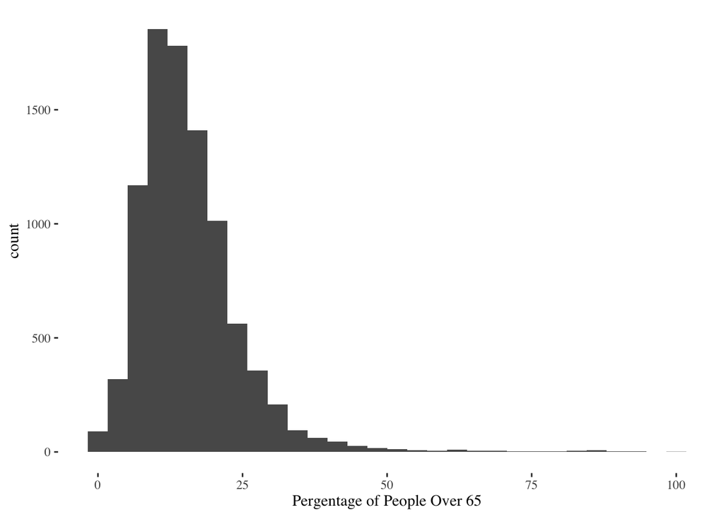

```r
eji_data |>
  filter(STATE_NAME=="California") |>
  ggplot(aes(x=E_AGE65)) +
  geom_histogram() +
  labs(x = "Pergentage of People Over 65") +
  theme_tufte()
```

If we use EPL_AGE65 in stead of E_AGE65, we can stretch out the densest part of the data and get a slightly clearer story.

I want to see if any other risk factors might explain how much coronary artery disease we see in different populations. I’m going to look at diabetes (E_DIABETES) incidence and environmental burden. E_DIABETES is the percentage of people in a tract with diabetes, and environmental burden is an index of a bunch of different things taht describe the environmental burden a tract experiences.

I’m going to play around with just California for a little bit so the my plots don’t take so long to render.

First diabetes.

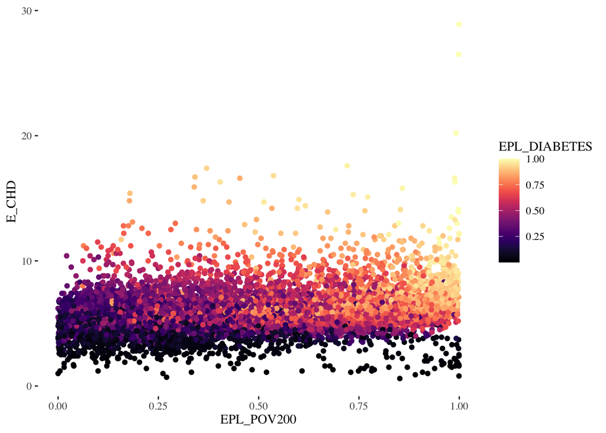

```r
eji_data |>
  filter(STATE_NAME=="California") |>
  ggplot(aes(x=EPL_POV200, y=E_CHD, color=EPL_DIABETES)) +
  geom_point() +
  scale_color_viridis(option="magma") +
  # labs(x = "Percentage of People with Diabetes",
  #      y = "Coronary heart disease prevalence (%)") +
  theme_tufte()
```

Now environmental burden.

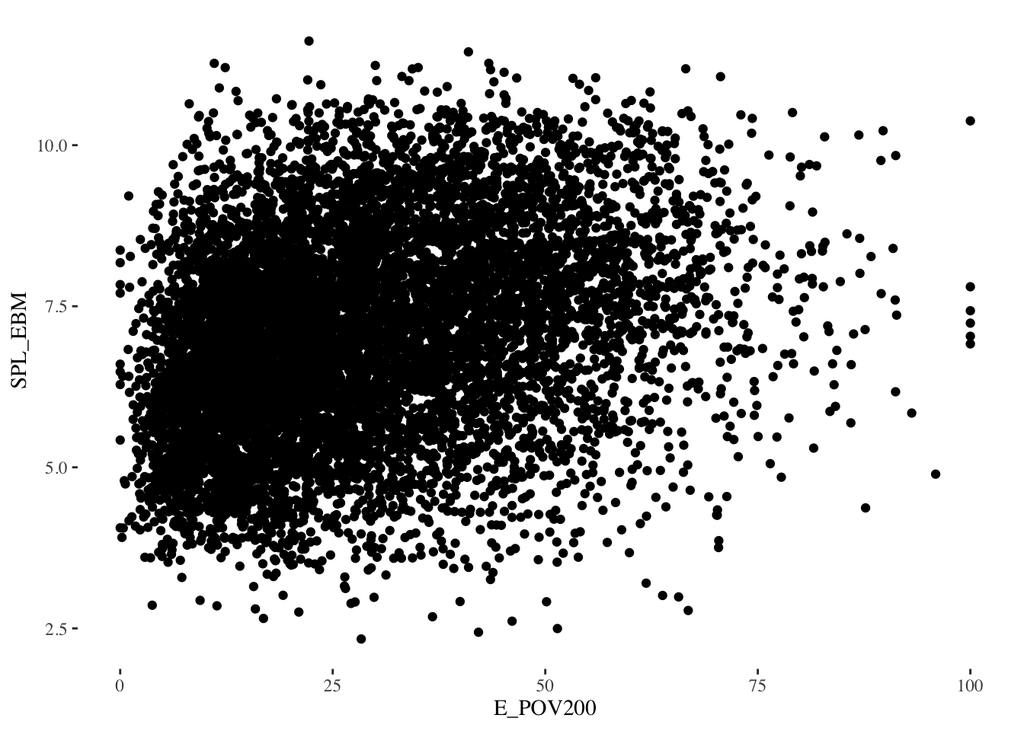

```r
eji_data |>
  filter(STATE_NAME=="California") |>
  ggplot(aes(x=E_POV200, y=SPL_EBM)) +
  geom_point() +
  #scale_color_viridis(option="magma") +
  # labs(x = "Percentage of People with Diabetes",
  #      y = "Coronary heart disease prevalence (%)") +
  theme_tufte()
```

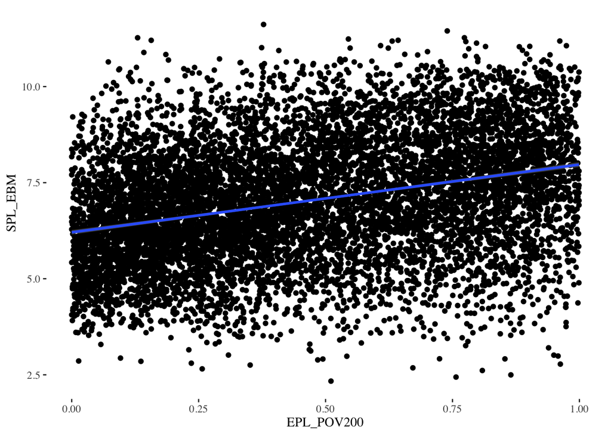

```r
eji_data |>
  filter(STATE_NAME=="California") |>
  ggplot(aes(x=EPL_POV200, y=SPL_EBM)) +
  geom_point() +
  geom_smooth(method="lm") +
  #scale_color_viridis(option="magma") +
  # labs(x = "Percentage of People with Diabetes",
  #      y = "Coronary heart disease prevalence (%)") +
  theme_tufte()
```

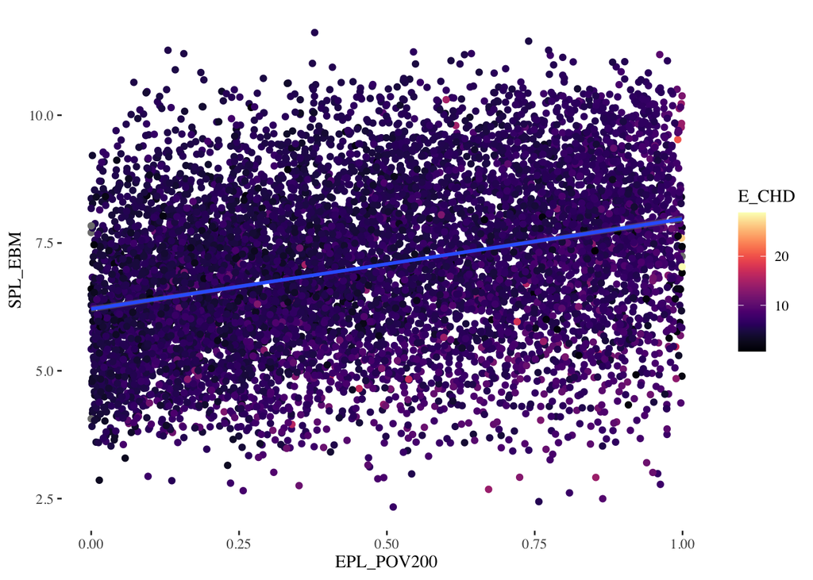

```r
eji_data |>
  filter(STATE_NAME=="California") |>
  ggplot(aes(x=EPL_POV200, y=SPL_EBM, color=E_CHD)) +
  geom_point() +
  geom_smooth(method="lm") +
  scale_color_viridis(option="magma") +
  # labs(x = "Percentage of People with Diabetes",
  #      y = "Coronary heart disease prevalence (%)") +
  theme_tufte()
```

There is a clear relationship between poverty and environmental burden, but the primary relationship I see when I add coronary heart disease is the relationship between poverty and coronary heart disease and the color goes from darker to lighter as you move from low poverty to high poverty. If anything coronary heart disease is higher at a lower environmental burden. My conclusion is that environmental burden is not a significant risk factor for coronary heart disease.

I’ve lost my focus. I think my question is something along the lines of what does poverty cost you in this country. You are definitely at higher risk for coronary heart disease. This becomes more pronounced if you are older and if you have additional risk factors like diabetes.

How much does your risk of having coronary heart disease increase in older populations if they are also poor. Let’s make some groups with more than 12% of the population over 65 and at the high and low ends of the poverty spectrum. I messed around with a bunch of options. Starting with just the boxplot and then adding additional groups and then finally the jitter in the background.

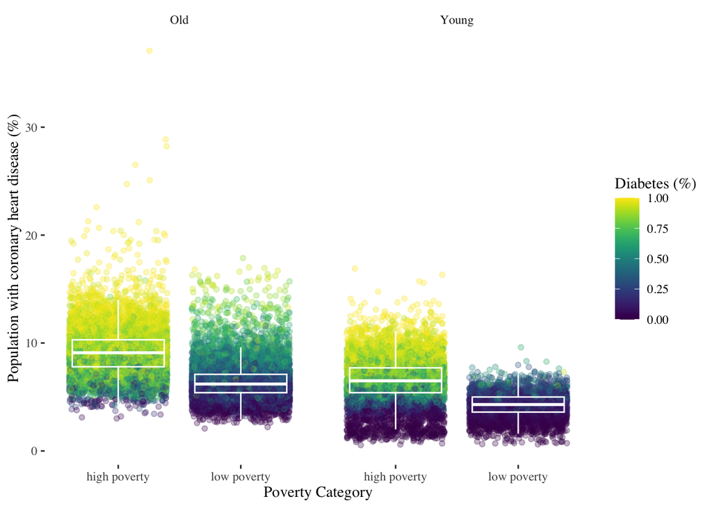

```r
eji_data |>
  mutate(age_cat= case_when(E_AGE65 > 12 ~ "Old",
                            E_AGE65 <= 12 ~ "Young")) |>
  mutate(pov_cat=case_when(EPL_POV200 < 0.25 ~ "low poverty",
                           EPL_POV200 > 0.75 ~ "high poverty",
                           TRUE ~ NA)) |>
  drop_na(pov_cat) |>
  ggplot(aes(x=pov_cat, y=E_CHD)) +
  geom_jitter(aes(color=EPL_DIABETES), alpha=0.3) +
  geom_boxplot(fill=NA, outliers=FALSE, color="white", alpha=0.7) +
  scale_color_viridis() +
  labs(x="Poverty Category",
       y="Population with coronary heart disease (%)",
       color = "Diabetes (%)") +
  theme_tufte() +
  facet_wrap(~age_cat)
```

My guiding question is what does poverty cost you in the United States, in terms of health and how do these factors interact.

What things might mitigate this trend? Turns out Walkability Index is almost as transformative as diabetes in explaining the vertical distribution of coronary heart disease.

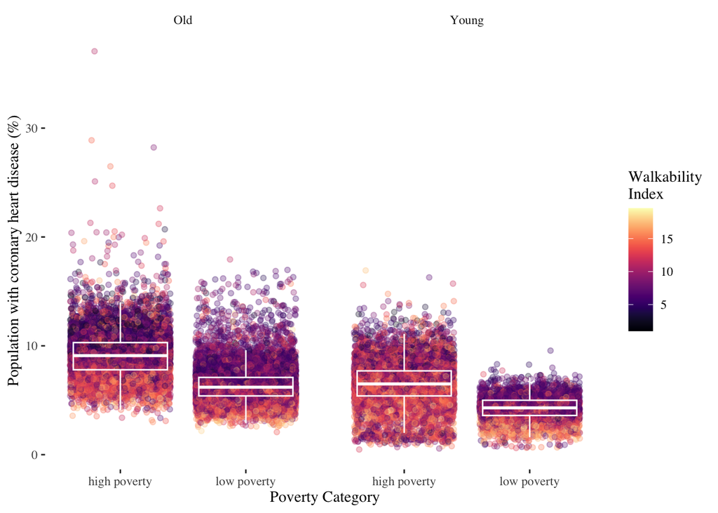

```r
eji_data |>
  mutate(age_cat= case_when(E_AGE65 > 12 ~ "Old",
                            E_AGE65 <= 12 ~ "Young")) |>
  mutate(pov_cat=case_when(EPL_POV200 < 0.25 ~ "low poverty",
                           EPL_POV200 > 0.75 ~ "high poverty",
                           TRUE ~ NA)) |>
  drop_na(pov_cat) |>
  ggplot(aes(x=pov_cat, y=E_CHD)) +
  geom_jitter(aes(color=E_WLKIND), alpha=0.3) +
  geom_boxplot(fill=NA, outliers=FALSE, color="white", alpha=0.7) +
  scale_color_viridis(option="magma") +
  labs(x="Poverty Category",
       y="Population with coronary heart disease (%)",
       color = "Walkability\nIndex") +
  theme_tufte() +
  facet_wrap(~age_cat)
```

High walkability index, results in substantially lower rates of coronary heart disease in all groupings, though the relationship is not as strong in young communities in high poverty areas.

## Here is my story:

We see a strong relationship between coronary heart disease across the poverty gradient. On significant explanatory variable is age. And in fact it is a little hard to determine how much age matters across the poverty gradient.

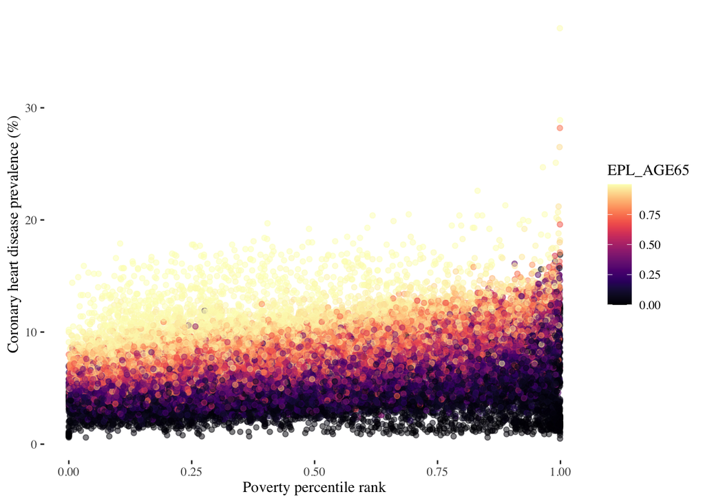

```r
eji_data |>
  #filter(STATE_NAME=="California") |>
  ggplot(aes(x=EPL_POV200, y=E_CHD)) +
  geom_point(aes(color=EPL_AGE65), alpha=0.5) +
  scale_color_viridis(option="magma") +
  labs(x = "Poverty percentile rank",
       y = "Coronary heart disease prevalence (%)") +
  theme_tufte()
```

To Explore this relationship further, I separated my data into old and young communities using a 12% cutoff for the percentage of people in the community over 65. I then created two more groupings from poverty, taking the wealthiest communities (below the 25% percentile rank) and the poorest communities (above the 75% percentile rank for percentage of people with incomes below the 200% federal poverty level). I then compared the incidence of coronary heart disease within these groupings.

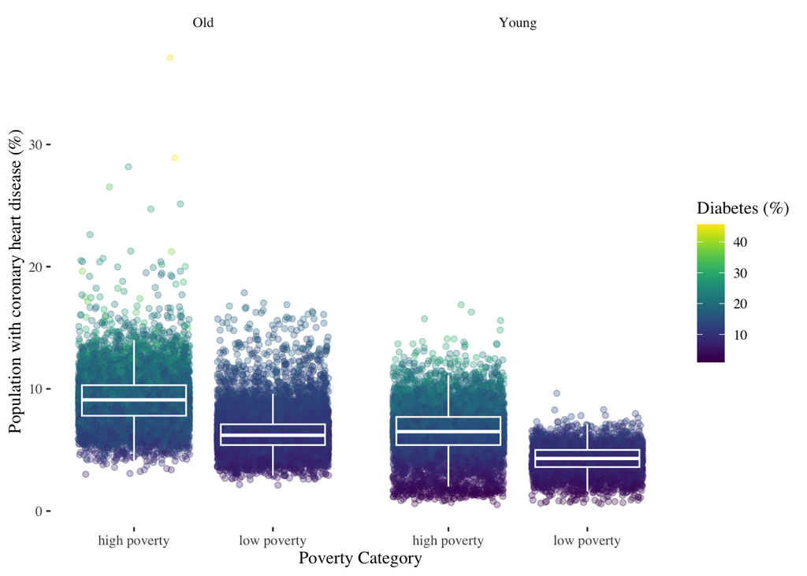

```r
eji_data |>
  mutate(age_cat= case_when(E_AGE65 > 12 ~ "Old",
                            E_AGE65 <= 12 ~ "Young")) |>
  mutate(pov_cat=case_when(EPL_POV200 < 0.25 ~ "low poverty",
                           EPL_POV200 > 0.75 ~ "high poverty",
                           TRUE ~ NA)) |>
  drop_na(pov_cat) |>
  ggplot(aes(x=pov_cat, y=E_CHD)) +
  geom_jitter(aes(color=E_DIABETES), alpha=0.3) +
  geom_boxplot(fill=NA, outliers=FALSE, color="white", alpha=0.7) +
  scale_color_viridis() +
  labs(x="Poverty Category",
       y="Population with coronary heart disease (%)",
       color = "Diabetes (%)") +
  theme_tufte() +
  facet_wrap(~age_cat)
```

I also added diabetes across the gradient of coronary heart disease incidence within each community grouping. Within each grouping of community age and poverty level diabetes and coronary heart disease showed a strong relationship, with increasing diabetes associated with increasing coronary heart disease.

I wanted to then explore what mitigating factors might drive coronary heart disease down within each of these community groupings. So I examined walkability index within each grouping. Walkability index is a measure developed by the U.S. Environmental Protection Agency (EPA) to describe how supportive a neighborhood’s built environment is for walking. While the EPI dataset does not include data on individual behaviors, I am using this as a proxy for physical activity.

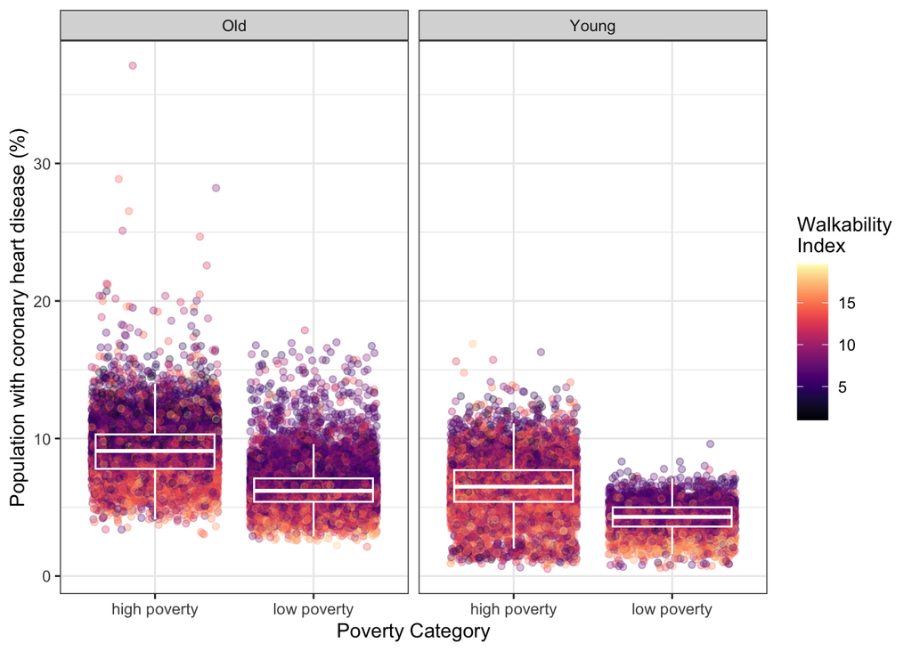

```r
eji_data |>
  mutate(age_cat= case_when(E_AGE65 > 12 ~ "Old",
                            E_AGE65 <= 12 ~ "Young")) |>
  mutate(pov_cat=case_when(EPL_POV200 < 0.25 ~ "low poverty",
                           EPL_POV200 > 0.75 ~ "high poverty",
                           TRUE ~ NA)) |>
  drop_na(pov_cat) |>
  ggplot(aes(x=pov_cat, y=E_CHD)) +
  geom_jitter(aes(color=E_WLKIND), alpha=0.3) +
  geom_boxplot(fill=NA, outliers=FALSE, color="white", alpha=0.7) +
  scale_color_viridis(option="magma") +
  labs(x="Poverty Category",
       y="Population with coronary heart disease (%)",
       color = "Walkability\nIndex") +
  theme_bw() +
  facet_wrap(~age_cat)
```

Increasing walkability index, is associated with substantially lower rates of coronary heart disease in all groupings. This pattern is almost as dramatic as the one seen in the increase of coronary heart disease with diabetes. This strongly hints at a relationship between walkability index and diabetes.

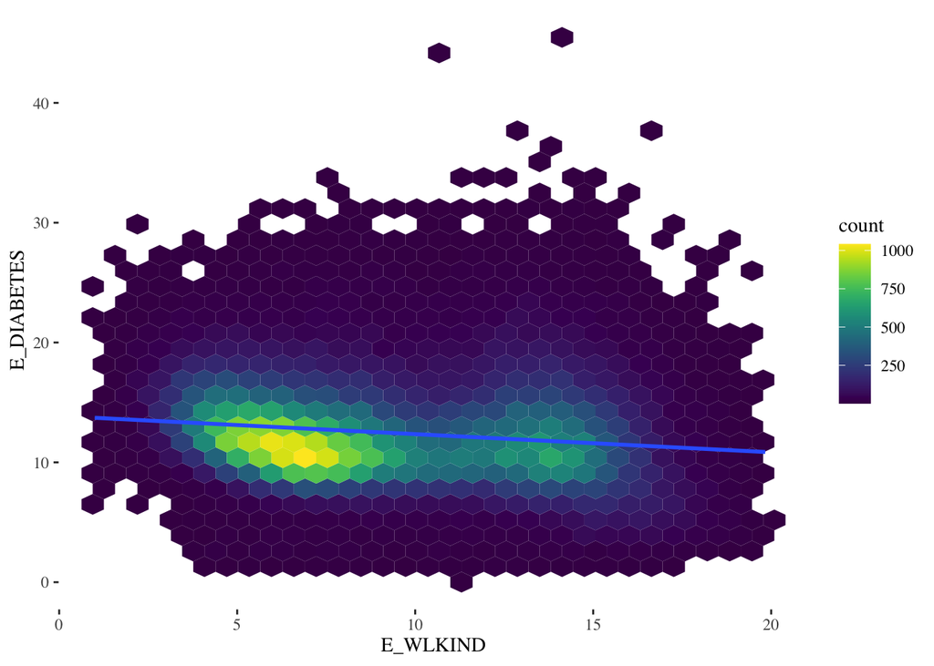

```r
eji_data |>
  #filter(STATE_NAME=="California") |>
  ggplot(aes(x=E_WLKIND, y=E_DIABETES)) +
  geom_hex() +
  geom_smooth(method="lm") +
  scale_fill_viridis() +
  theme_tufte()
```

When we examine this relationship, we do see a very weak relationship with diabetes decreasing slightly across the spectrum of walkability index. However, the earlier version has a much more pronounced pattern within our groupings.

What conclusions can we draw from this?

Don’t get old, and walk a lot?

# Groups - Closing Discussion

In your groups, discuss the following questions. Think about what you learned from today’s examples, how you might apply it to your own projects, and what you’d like to explore next.

1. What did you learn? Was there something from today’s examples that you could apply to your own project?
2. What did you notice about the process? How did we approach questions when the answers weren’t immediately obvious?
3. What’s your next step? Based on today’s discussion, what will you try next in your analysis?
4. As a group, identify one useful idea or strategy from today’s class to share with everyone.